# HW1

Dorothy Gay, Monica Martinez-Raga, Patrick Sinclair

9/11/2020

## Question 3 - Dice Roll

### Part 1 - A Fair Die

By setting the interval 1:6 as an R Object **die**, we were able to write a function that generates a random sample of numbers from the interval. We allowed the sample to replace outcomes so the function simulates a roll of a fair die and set the sample size to 20.

The command **dice** will produce the same set of randomly generated numbers each time it is executed. If we wish to view different outcomes, we can execute the function **roll**.

```r
dice
```

```
##  [1] 2 2 6 3 4 6 3 6 6 2 5 5 4 1 3 4 6 1 6 1
```

```r
roll()
```

```
##  [1] 4 6 6 5 4 5 6 2 1 3 4 5 3 5 3 2 4 4 5 6
```

Using classical probability, we would expect to see a 6 from the roll of a fair die 1/6 times. For 20 trials, we would expect 6 to be the result 20*(1/6) = 3.33 times.

### Part 2 - Adjusted Dice

To adjust our die, we created a new function for sampling the object “die” and adjusted the probability within the function. Initially we had changed the sample size and prevented the sample from replacing outcomes but adjusting the probability of each outcome made for a more challenging and interesting learning experience!

```r
# rollw <- function(die = 1:6){
#   dice <- sample(die, size = 20, replace = TRUE, prob = c(1/10, 1/10, 1/10, 1/10, 1/10, 1/2))
#   dice
#   }
# dicew <- sample(die, size = 20, replace = TRUE, prob = c(1/10, 1/10, 1/10, 1/10, 1/10, 1/2))
```

As with our fair die, the object *dicew* will return the same set of weighted outcomes. *rollw* will produce a new set of outcomes each time it is executed.

```r
dicew
```

```
##  [1] 3 6 4 5 1 2 6 6 4 1 6 5 6 3 3 2 6 2 6 6
```

```r
rollw()
```

```
##  [1] 1 2 6 5 6 2 1 4 4 6 6 1 6 6 6 2 6 2 1 6
```

## Question 4 - PUMS Data

### Part 1 - Replicating Commands from R Basics for Lecture I

Below is a summary of all the data.

```r
summary(acs2017_ny)
```

```
##       AGE            female         educ_nohs        educ_hs
##  Min.   : 0.00   Min.   :0.0000   Min.   :0.000   Min.   :0.0000
##  1st Qu.:22.00   1st Qu.:0.0000   1st Qu.:0.000   1st Qu.:0.0000
##  Median :42.00   Median :1.0000   Median :0.000   Median :0.0000
##  Mean   :41.57   Mean   :0.5156   Mean   :0.271   Mean   :0.2804
##  3rd Qu.:60.00   3rd Qu.:1.0000   3rd Qu.:1.000   3rd Qu.:1.0000
##  Max.   :95.00   Max.   :1.0000   Max.   :1.000   Max.   :1.0000
##
##  educ_somecoll    educ_college     educ_advdeg                  SCHOOL
##  Min.   :0.000   Min.   :0.0000   Min.   :0.000   N/A              :  5569
##  1st Qu.:0.000   1st Qu.:0.0000   1st Qu.:0.000   No, not in school:144968
##  Median :0.000   Median :0.0000   Median :0.000   Yes, in school   : 46048
##  Mean   :0.173   Mean   :0.1567   Mean   :0.119   Missing          :     0
##  3rd Qu.:0.000   3rd Qu.:0.0000   3rd Qu.:0.000
##  Max.   :1.000   Max.   :1.0000   Max.   :1.000
##
##                         EDUC
##  Grade 12                 :55119
##  4 years of college       :30802
##  5+ years of college      :23385
##  1 year of college        :19947
##  Nursery school to grade 4:14240
##  2 years of college       :14065
##  (Other)                  :39027
##                                           EDUCD
##  Regular high school diploma                 :35689
##  Bachelor's degree                           :30802
##  1 or more years of college credit, no degree:19947
##  Master's degree                             :17010
##  Associate's degree, type not specified      :14065
##  Some college, but less than 1 year          : 9086
##  (Other)                                     :69986
##                                      DEGFIELD
##  N/A                                     :142398
##  Business                                :  9802
##  Education Administration and Teaching   :  6708
##  Social Sciences                         :  4836
##  Medical and Health Sciences and Services:  3919
##  Fine Arts                               :  3491
##  (Other)                                 : 25431
```

[output cut: 209 more lines]

```
##  Min.   :0.00000   Min.   :0.00000   Min.   :0.000     Min.   :0.0000
##  1st Qu.:0.00000   1st Qu.:0.00000   1st Qu.:0.000     1st Qu.:0.0000
##  Median :0.00000   Median :0.00000   Median :0.000     Median :0.0000
##  Mean   :0.01332   Mean   :0.05506   Mean   :0.122     Mean   :0.1965
##  3rd Qu.:0.00000   3rd Qu.:0.00000   3rd Qu.:0.000     3rd Qu.:0.0000
##  Max.   :1.00000   Max.   :1.00000   Max.   :1.000     Max.   :1.0000
##
##  below_200poverty   foodstamps
##  Min.   :0.0000   Min.   :0.0000
##  1st Qu.:0.0000   1st Qu.:0.0000
##  Median :0.0000   Median :0.0000
##  Mean   :0.2676   Mean   :0.1465
##  3rd Qu.:1.0000   3rd Qu.:0.0000
##  Max.   :1.0000   Max.   :1.0000
##
```

The following code shows there are 196,585 rows in the dataset.

```r
print(NN_obs <- length(AGE))
```

```
## [1] 196585
```

The mean age of women in NYC is 42.72 years.

```r
summary(AGE[female == 1])
```

```
##    Min. 1st Qu.  Median    Mean 3rd Qu.    Max.
##    0.00   23.00   44.00   42.72   61.00   95.00
```

The mean age of men in NYC is 40.35 years.

```r
summary(AGE[!female])
```

```
##    Min. 1st Qu.  Median    Mean 3rd Qu.    Max.
##    0.00   21.00   40.00   40.35   59.00   95.00
```

Alternative ways to access summary figures: Female age statistics

```r
mean(AGE[female == 1])
```

```
## [1] 42.71629
```

```r
sd(AGE[female == 1])
```

```
## [1] 23.72012
```

Male age statistics

```r
mean(AGE[!female])
```

```
## [1] 40.35398
```

```r
sd(AGE[!female])
```

```
## [1] 23.1098
```

### Part 2 - Interesting Finds

For the purpose of exploring interesting statistics in the data, we wanted to find differences in education attainment levels in men and women. The results indicate that women generally attain more and higher levels of formal education, and men had lower rates of high school completion.

```r
educ_indx <- factor((educ_nohs + 2*educ_hs + 3*educ_somecoll + 4*educ_college + 5*educ_advdeg), levels=c(1,2,3,4,5),labels = c("No HS","HS","SmColl","Bach","Adv"))
table(educ_indx,female)
```

```
##          female
## educ_indx     0     1
##    No HS  27180 26087
##    HS     27309 27810
##    SmColl 15847 18165
##    Bach   14632 16170
##    Adv    10254 13131
```

## Question 5 - SP500 Index

### Part 1 - Mean for time frame February 20, 2020 - September 1, 2020

Here we load in the SP500 data from 2-20-2020 to 9-1-2020

```r
library(readr)
library(dplyr)
library(ggplot2)

S_P <- read_csv("S&P.csv")
```

```r
knitr::kable(summary(S_P))
```

|  | Date | Open | High | Low | Close | Adj Close | Volume |
| --- | --- | --- | --- | --- | --- | --- | --- |
|  | Min. :2020-02-20 | Min. :2291 | Min. :2301 | Min. :2192 | Min. :2237 | Min. :2237 | Min. :3.193e+09 |
|  | 1st Qu.:2020-04-07 | 1st Qu.:2839 | 1st Qu.:2868 | 1st Qu.:2803 | 1st Qu.:2845 | 1st Qu.:2845 | 1st Qu.:4.473e+09 |
|  | Median :2020-05-27 | Median :3064 | Median :3090 | Median :3014 | Median :3054 | Median :3054 | Median :5.123e+09 |
|  | Mean :2020-05-27 | Mean :3018 | Mean :3047 | Mean :2985 | Mean :3018 | Mean :3018 | Mean :5.499e+09 |
|  | 3rd Qu.:2020-07-15 | 3rd Qu.:3225 | 3rd Qu.:3242 | 3rd Qu.:3205 | 3rd Qu.:3226 | 3rd Qu.:3226 | 3rd Qu.:6.373e+09 |
|  | Max. :2020-09-01 | Max. :3510 | Max. :3528 | Max. :3495 | Max. :3527 | Max. :3527 | Max. :9.045e+09 |

Here we will add in a column called “Return”, calculated from the day’s (Close-Open). Here are the concatenated results.

```r
S_P$Return <- S_P$Close-S_P$Open
knitr::kable(head(S_P, n = 5))
```

| Date | Open | High | Low | Close | Adj Close | Volume | Return |
| --- | --- | --- | --- | --- | --- | --- | --- |
| 2020-02-20 | 3380.45 | 3389.15 | 3341.02 | 3373.23 | 3373.23 | 4007320000 | -7.219971 |
| 2020-02-21 | 3360.50 | 3360.76 | 3328.45 | 3337.75 | 3337.75 | 3899270000 | -22.750000 |
| 2020-02-24 | 3257.61 | 3259.81 | 3214.65 | 3225.89 | 3225.89 | 4842960000 | -31.720214 |
| 2020-02-25 | 3238.94 | 3246.99 | 3118.77 | 3128.21 | 3128.21 | 5591510000 | -110.729980 |
| 2020-02-26 | 3139.90 | 3182.51 | 3108.99 | 3116.39 | 3116.39 | 5478110000 | -23.510009 |

From “Return” we can calculate the mean.

```r
knitr::kable(mean(S_P$Return))
```

| x |
| --- |
| 0.1786087 |

### Part 2 - Mean Return On The Day After a Previous Day’s Return Was Positive or Negative

Here we will utilize a Lead/Lag function to determine “Previous Return” based on a previous day’s return.

```r
S_P$PreviousReturn <- lag(S_P$Return)
knitr::kable(head(S_P, 5))
```

| Date | Open | High | Low | Close | Adj Close | Volume | Return | PreviousReturn |
| --- | --- | --- | --- | --- | --- | --- | --- | --- |
| 2020-02-20 | 3380.45 | 3389.15 | 3341.02 | 3373.23 | 3373.23 | 4007320000 | -7.219971 | NA |
| 2020-02-21 | 3360.50 | 3360.76 | 3328.45 | 3337.75 | 3337.75 | 3899270000 | -22.750000 | -7.219971 |
| 2020-02-24 | 3257.61 | 3259.81 | 3214.65 | 3225.89 | 3225.89 | 4842960000 | -31.720214 | -22.750000 |
| 2020-02-25 | 3238.94 | 3246.99 | 3118.77 | 3128.21 | 3128.21 | 5591510000 | -110.729980 | -31.720214 |
| 2020-02-26 | 3139.90 | 3182.51 | 3108.99 | 3116.39 | 3116.39 | 5478110000 | -23.510009 | -110.729980 |

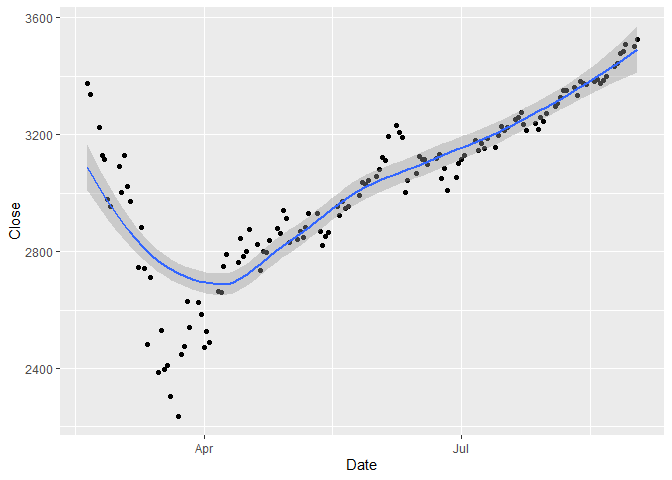

```r
ggplot(data=S_P, aes(x=Date, y=Close), name="Close over time") + geom_point() + geom_smooth()
```

Here we filter “PreviousReturn” to find the previous day’s return values that are positive. In the summary we can see the mean return on a previous day’s positive return is -7.9192.

```r
summary(filter(S_P, PreviousReturn >= 0) $Return)
```

```
##      Min.   1st Qu.    Median      Mean   3rd Qu.      Max.
## -127.0200  -22.4602   -0.4399   -7.9192   14.4600  128.7800
```

Similarly, we can filter by and summarize negative “PreviousReturn” values to find the mean returns on days where the previous day’s return values were negative. As shown, the mean returns on these days are 11.06.

```r
summary(filter(S_P, PreviousReturn <= 0) $Return)
```

```
##    Min. 1st Qu.  Median    Mean 3rd Qu.    Max.
## -150.22  -23.15   19.18   11.06   36.53  141.03
```

### Part 3 - Mean Return On The Day After a Previous Two Day’s Returns Were Positive or Negative

To determine mean on days where the previous two day’s returns were negative we simply set another conditional to consider values where returns on both days prior were negative - where the mean is 10.67:

```r
S_P$PreviousTwoDayReturn <- lag(S_P$PreviousReturn)
summary(filter(S_P, PreviousReturn <= 0 & PreviousTwoDayReturn <= 0) $Return)
```

```
##    Min. 1st Qu.  Median    Mean 3rd Qu.    Max.
## -121.43  -28.17   16.64   10.67   52.80  141.03
```

And when returns on two days prior are positive where the mean is 2.295:

```r
S_P$PreviousTwoDayReturn <- lag(S_P$PreviousReturn)
summary(filter(S_P, PreviousReturn >= 0 & PreviousTwoDayReturn >= 0) $Return)
```

```
##    Min. 1st Qu.  Median    Mean 3rd Qu.    Max.
## -93.090 -13.027   4.310   2.295  15.713 128.780
```

### Part 4 - The Hot Hands Fallacy and How It Relates To Our Findings

```r
ReturnsBasedOnHistory <- matrix(c(-7.9192,11.0600,2.2950,10.6700
), ncol=2)
colnames(ReturnsBasedOnHistory) <- c('Past Day Return', 'Past Two Days Return')
rownames(ReturnsBasedOnHistory) <- c('Positive', 'Negative')
ReturnsBasedOnHistory.table <- as.table(ReturnsBasedOnHistory)
ReturnsBasedOnHistory
```

```
##          Past Day Return Past Two Days Return
## Positive         -7.9192                2.295
## Negative         11.0600               10.670
```

Based on the data from SP500 spanning from February 20, 2020 - September 1, 2020, we notice that the day after a positive return, the mean return is strongly negative. However, the day after two positive returns, the mean return comes up slightly back to positive. Similarly, the day after a negative return, the mean return is starkly positive but after two days the positivity of the return decreases. From here we can infer that with a larger sample size, the returns based on historical movement begin to normalize, approaching the mean of the entire time frame’s return of 0.1786.

### Part 5 - A Question For Discussion

Given institutions have greater ability to be selective in making their predictions when assessing streaks in the market, are they able to leverage trading large volumes to manipulate whether positive return streaks continue or cease?